# stranger for the impatient

WeLoveDataScience

2018-03-12

# I am so impatient: I want to Get some anomalies!

Okay… so you checked your favorite method is here. Let’s say k-nearest neightbors as implemented in `FNN` package.

Very impatient people may detect some suspicious records using `lucky_odds` - though we recommend being a little more patient: unsupervised anomaly detection requires some patience.

## Stop talking: show now!

Loading package.

```r
library(stranger)
```

`FNN` package will be automatically loaded. At this step ensure it is currently available (installed) in your environment.

On our favorite classical dataset, we perform computations directly followed by visualisation of top 6 anomalies according to our knn approach.

```r
anomalies <- iris %>% lucky_odds(n.anom=6, weird="knn", analysis.drop="Species")
```

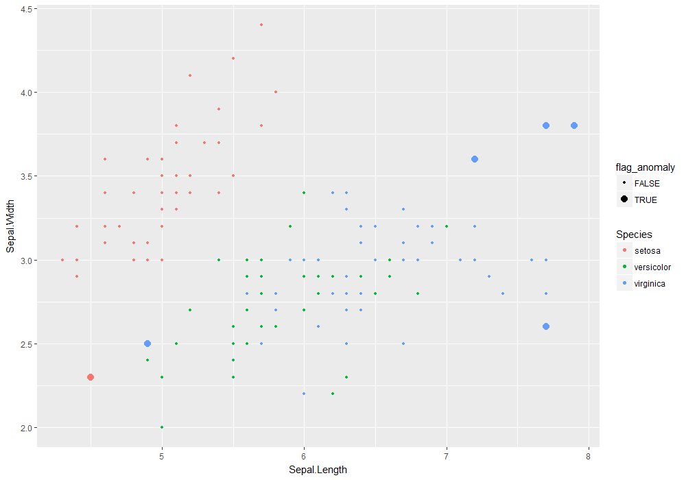

```r
anomalies %>% ggplot(aes(x=Sepal.Length,y=Sepal.Width,color=Species,size=flag_anomaly))+
  geom_point()+
  scale_size_discrete(range=c(1,3))
```

## Uh? What happened?

> Yeks! That is very few commands! And I don’t clearly see what happened. Can you explain?

Sure. You ask for 6 anomalies using `knn` weird method, as computed on all numeric variables of `iris` dataset. As this method is you preferred one, you may know it has / should have some parameters.

We defined some default for you (no certitude they are the best ones…). Don’t worry, you will be able to modify them according to your preferences/needs.

There are several things that happened in the background - corresponding to `stranger` analysis flow.

There is clearly no assurance that `lucky_odds` gives you relevant anomalies, hence the *lucky* part of the name. Still this function has some parameters that can give you some control on the outputs but knowing the detailed process will allow you better understand those parameters.

# Anomaly detection process with stranger

In `stanger`, we have decomposed the process in some components having associated verbs.

- **Data Preparation**: you can’t just expect right anomalies if you don’t perform some preliminary steps on data. First, most of anomalies detection routines just can’t handle missing values. It is up to the user to handle that aspect before doing analysis (well… we propose two very simple methods for the very impatient user). Then, the process will be more relevant if you give as input variable having comparable ranges. For that, we propose to normalize or rescale within [0,1] interval. Other treatment we propose is to recode skewed distribution (taking the logarithm) and the usage of ITDF to recode categorical variables. Though we recommend to perform data preparation outside `stranger` framework, the starting point that may already to what is recommended is the `crazyfy` function. Invoking this verb is mandatory in our process.
- **Computational part**: on *crazyfied* data, one can apply one or several *weirds* methods to retrieve associated anomalies metrics. This could be done with either `strange` (one weird method) or `stranger` (severall weirds methods at one) functions. Note that at this step we may end up with various metrics potentially incompatible (distance versus probability). This leads to the next step:
- **Metrics standardisation and stacking** In order to end up with comparable metrics, we normalize them depending on their algorithm and nature. In addition, we derive several global anomaly indicators by stacking the (eventual) multiple metrics you have (for instance averaging or taking the minimum of ranked metrics). This step is tackled by the `singularize` function. This step is optional and user will also be able to derive anomalies from raw metrics values (for instance considering abod metric > 2).
- **Get anomalies** This tricky part of specifying a criteria that determined is handled by `get_anomalies` or `as.anomalies` for manual selection on raw metrics. In addition, one may want to merge anomalies back to initial data (or other ones), which can be done through Hadley verb `fortify`.

***Merge back with data** Source data enrichment with either metrics or anomaly flags is performed thanks to dedicated `fortify` methods.

At every of those steps, user can fine-tune the analysis thanks to some parameters.

Here is an example of explicitely invoke the whole processes step by step.

```
##
## Ordering: -1xN_anom_norm_avg and -1xN_anom_norm_avg
##  0 outliers found by default with this stacking and this method, which is not enough to satisfy nmin= 6 . Following most probable outliers are added to selection.
```

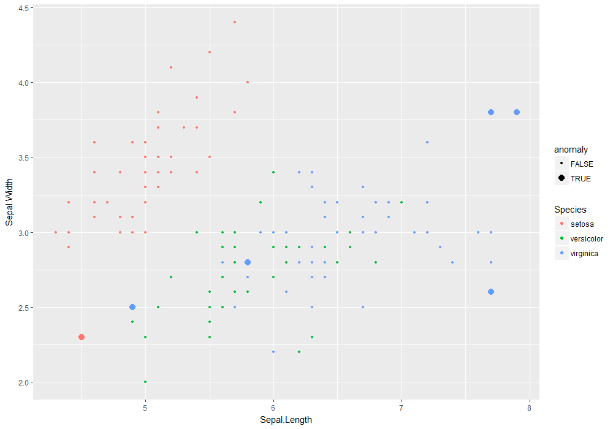

```r
iris %>% select(-Species) %>%       # remove Species - meaningless to define anomalies
  crazyfy() %>%                     # data preparation: add id, rescale [0,1], eventualy takes log
  strange("knn",k=5) %>%            # computes knn distances to 5 neighbors, aggregate distances with the mean (default)
  singularize() %>%                 # required step if no manual selection
  get_anomalies(nmin=6,nmax=10) %>%  # ask for some anomalies
  fortify(data=iris,colname="anomaly") %>%          # enrich iris dataset with a flag called "anomaly" (0/1)
  ggplot(aes(x=Sepal.Length,y=Sepal.Width,color=Species,size=anomaly))+   # let's view!
    geom_point()+
    scale_size_discrete(range=c(1,3))
```

# Got it! I want more!

## Visualize anomalies

Understanding the reasons behind the score of a suspicious record is quite important to help people to trust the models, even if they don’t fully understand them. Interpretability is also critical to facilitate model validation and investiagation of suspicious cases. Unfortunately, scores made by machine learning models are usually difficult to explain, especially to non-data scientists. So, we will show in this section how this problem of interpretability can be partially adressed with few plots on surrogate models. We know that small regions of the conditional distribution, such as the k-nearest neighboors of an input record and their corresponding score, can likely be approximated by linear model. So by only focusing on that small region, we can use simple models (i.e. a surrogate model) to explain locally the more complex global model and visualize these simple models with basic plots. There are however no guarantees that the surrogate model is highly representative of the more complex model. So make sure that the results of the surrogate models are in line with human domain knowledge.

All the provided plots zoom on a specific record and its k-nearest neighbours, but with a different view each time.

Today, 5 visualizations are implemented;

Those functions are available though `plot` methods, usable on the objects in various steps of the process.

For every graph, a given weird metric must be provided.

Let start for instance to build a `stranger` object called `is` from iris dataset with all default (`knn` *weird* with k=10).

```r
is <- iris %>%
   select(-Species) %>%
   crazyfy() %>%
   strange()
```

## Similarity between top anomalies

The option `type = "cluser"` shows a hierarchical cluster among the top highest score around a specif record. The plot on the top, called “Full Tree”, helps you to select the number of cluster according to the zoom level of your interest. The plot on the bottom, called " Zooming-in“, zooms in the cluster in which the selected records belongs to. Finding the commun pattern within a cluster (or sub-cluster) should provide you insights on what has driven the score.

```
## [1] 132
```

```
## Your data has been converted to a dataframe to be compatible with ggplot function.
```

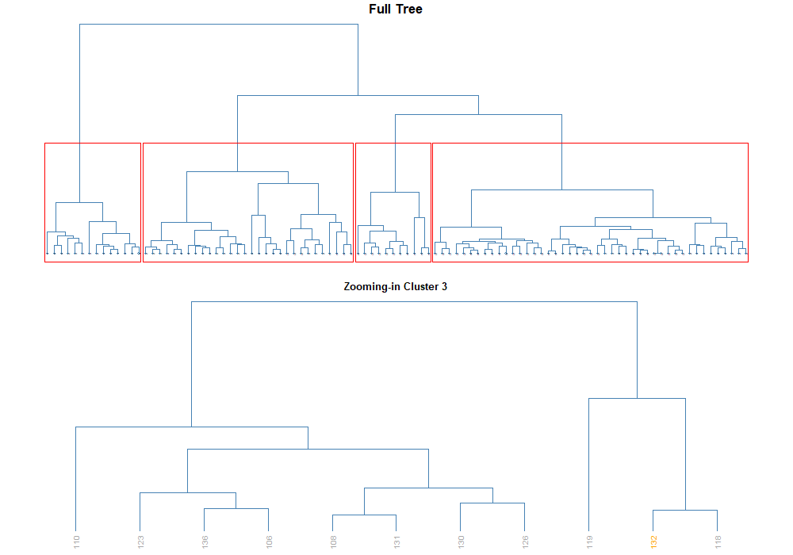

```r
is %>%   plot(type="cluster",score = "knn_k_10_mean")
```

### Note on unshown default parameters

Call with all parameters (except the ones specific to the type of plot) could be - with default values used:

```
## [1] 132
```

```
## Your data has been converted to a dataframe to be compatible with ggplot function.
```

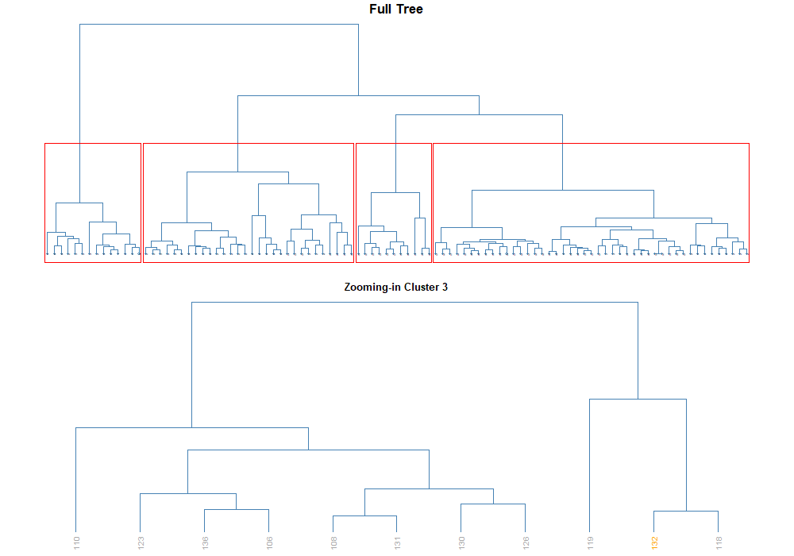

```r
is %>% plot (type="cluster",
id = ".id",
score = "knn_k_10_mean")
```

In `stranger` default process, required `id` is named **.id**, thus default value is suitable.

The parameter `anomaly_id` is used to pick one specific anomaly as identified by its id. Using the default value `NULL` the record having highest anomaly score (here based on **knn_k_10_mean**) is used.

## Univariate relationship

The option `type = "neighbours"` shows a dots plot with a loess regression that emphasis the relationship between the anomly score and each numerical feature for a specific record and its k-nearest neighbours.

```
## [1] 132
```

```
## Your data has been converted to a dataframe to be compatible with ggplot function.
```

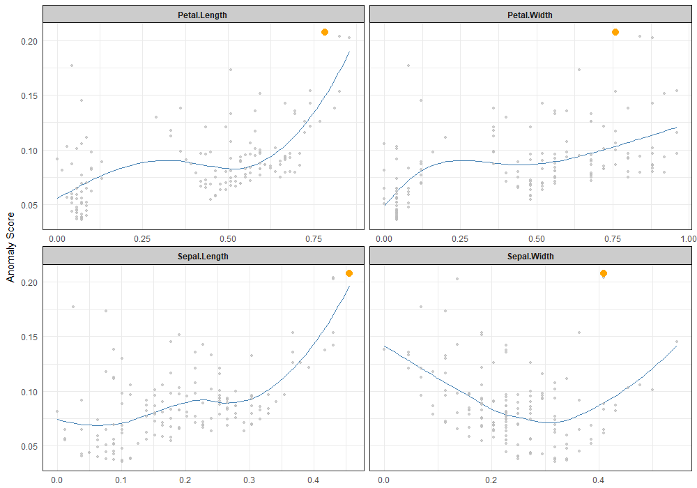

```r
is %>% plot (type="neighbours",score = "knn_k_10_mean")
```

## Decision tree

The option `type = "regression_tree"` shows roots to lead to high score locally around a specific record. The function use a pruned `rpart` regression tree where score is used as the dependent feature and all others feature as covariates. This approaches has been inspired by the model [LIME] (https://arxiv.org/pdf/1602.04938.pdf).

```
## [1] 132
```

```
## Your data has been converted to a dataframe to be compatible with ggplot function.
```

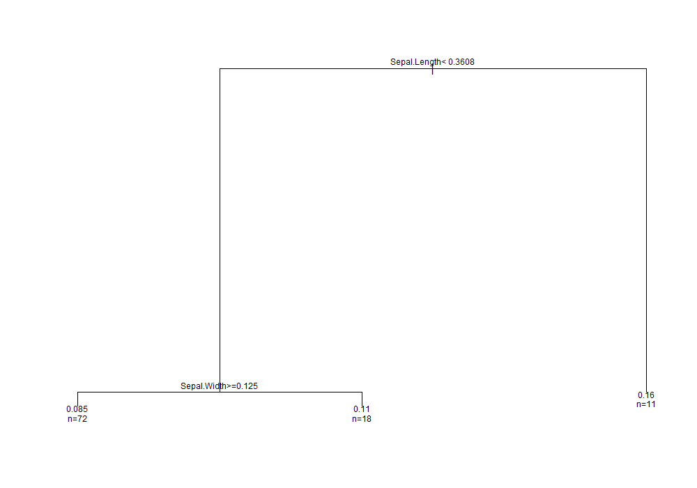

```r
is %>% plot(type="regression_tree",score = "knn_k_10_mean")
```

## Variables importance

The option `type = "feature_importance"` shows a dotplot sorted by decreasing variable importance. Such variable importance is derived from fitting a random forest using anomaly id as a target.

Due to the approach, this graphic is not suited for small data (both in terms of records and columns).

Fitting random forest is performed with `ranger` package for efficiency purpose.

Note that: - A list of id may be provided. - For that plot method, score should be specified and is only used when `anomaly_id` is `NULL` (to determine top anomaly).

```
## [1] 132
```

```
## Your data has been converted to a dataframe to be compatible with ggplot function.
```

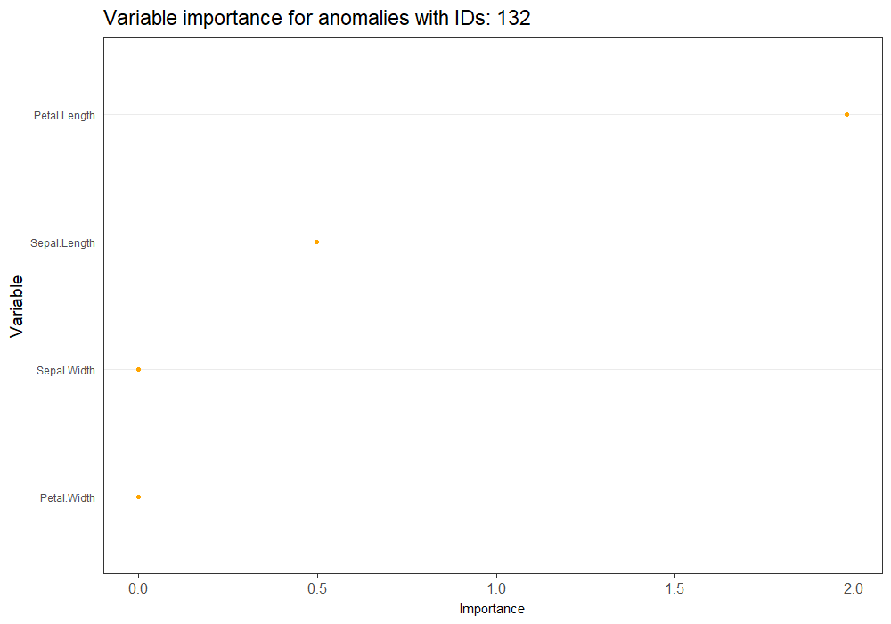

```r
is %>% plot (type="feature_importance",score = "knn_k_10_mean")
```

## Score decline

```
## [1] 132
```

```
## Your data has been converted to a dataframe to be compatible with ggplot function.
```

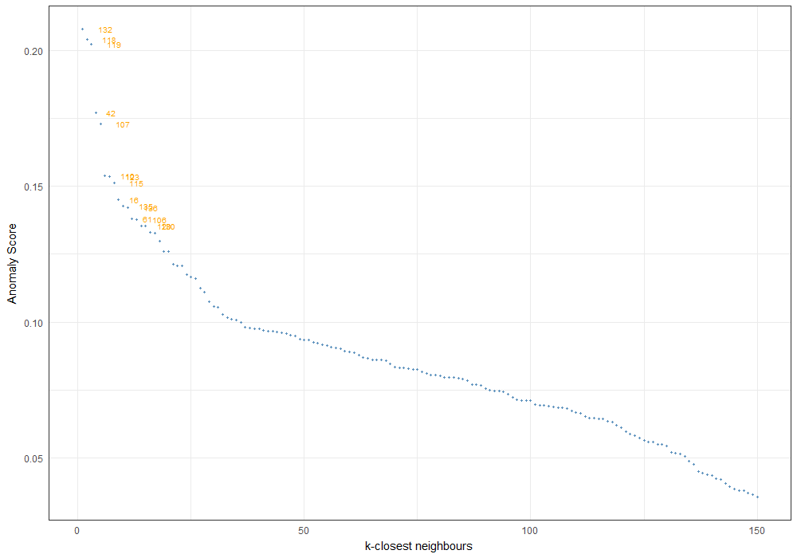

```r
is %>% plot(type="scores_decline",score = "knn_k_10_mean")
```

# To go further…

Explore additional vignettes. Next recommended vignette deals about working with several methods at once: * **Working with several methods** () introduce the usage of `stranger` function, the possibility to `merge` and stack (aggregate) methods with `singularize`.

Then you will be interested in knowing the list of available methods, which you can find there: * **Stranger weirds methods** (vignette) list all available *weirds* with some information on them.